# Capitulo 1

CAPITULO 1

Datos y estadística

ESTADÍSTICA EN LA PRÁCTICA: BUSINESSWEEK

1.1 **APLICACIONES EN NEGOCIOS Y ECONOMIA**

- Contabilidad
- Finanzas
- Marketing
- Producción
- Economía

1.2 **DATOS**

- Elementos, variables y observaciones
- Escalas de medición
- Datos categóricos y cuantitativos
- Datos de corte transversal y de series de tiempo

1.3 **FUENTE DE DATOS**

- Fuentes existentes
- Estudios estadísticos
- Errores en la adquisición de datos

1.4 **ESTADÍSTICA DESCRIPTIVA**

1.5 **INFERENCIA ESTADISTICA**

1.6 **COMPUTADORAS Y ANÁLISIS ESTADÍSTICO**

1.7 **MINERÍA DE DATOS**

1.8 **LINEAMIENTOS ÉTICOS PARA LA PRÁCTICA ESTADÍSTICA**

## 1.1 **Aplicaciones en negocios y economía**

En el entorno actual de negocios y economía, todos tienen acceso a grandes cantidades de información estadística. Los directivos y tomadores de decisiones exitosos entienden esta información y saben utilizarla de manera eficiente. En esta sección se proporcionan ejemplos que ilustran algunos usos de la estadística en los negocios y en la economía.

```python
from IPython.display import YouTubeVideo

YouTubeVideo('https://www.youtube.com/watch?v=15VqjabLWJE&list=PL3lPU7IsdhynPFg9q77hI4OBWrFrWnWrz', width=900, height=515)
```

[video not shown]

### **Contabilidad**

Las empresas de contadores públicos utilizan procedimientos de muestreo estadístico al realizar auditorías para sus clientes. Por ejemplo, supongamos que una empresa de contadores desea determinar si las cantidades en cuentas por cobrar que aparecen en la hoja de balance del cliente representan la verdadera cantidad en cuentas por cobrar. Revisar el gran número de cuentas por cobrar tomaría demasiado tiempo y sería muy costoso. En estos casos, el personal encargado de la auditoría selecciona un subconjunto de las cuentas, conocido como muestra. Después de revisar la exactitud de las cuentas seleccionadas en la muestra, los auditores concluyen si la cantidad en cuentas por cobrar que aparece en la hoja de balance del cliente es aceptable.

### **Finanzas**

Los analistas financieros utilizan información estadística para sus recomendaciones de inversión en acciones. Revisan datos como la relación precio/ganancia y el rendimiento de los dividendos. Comparan estos datos con el promedio del mercado de acciones para determinar si una acción está sobre o subvaluada.

### **Marketing**

Los escáneres electrónicos en las cajas de los comercios minoristas recopilan datos para la investigación de mercado. Estos datos se venden a proveedores como ACNielsen e Information Research Inc., quienes los procesan y venden resúmenes estadísticos a los fabricantes. Estos datos son útiles para analizar la relación entre las actividades promocionales y las ventas, lo que ayuda a establecer estrategias de marketing.

### **Producción**

En la producción, la calidad es importante y se utiliza la estadística para controlarla. Se emplean gráficas de control estadístico de calidad, como la gráfica x-barra, para vigilar los resultados promedio de los procesos de producción. Si los puntos en la gráfica están dentro de los límites de control, el proceso puede continuar sin ajustes.

### **Economía**

Los economistas utilizan información estadística para hacer pronósticos sobre la economía. Por ejemplo, emplean indicadores como el índice de precios al consumidor, la tasa de desempleo y la utilización de la capacidad de producción para pronosticar las tasas de inflación. Estos indicadores se utilizan en modelos computarizados de pronósticos.

En este libro se presentan ejemplos que ejemplifican la diversidad de las aplicaciones estadísticas. Además, se incluyen los artículos "La estadística en la práctica" al comienzo de cada capítulo, donde se muestra el material que será estudiado. Estas aplicaciones demuestran la importancia de la estadística en situaciones relacionadas con los negocios y la economía.

## 1.2 **Datos**

```python
YouTubeVideo('uacITE-8k-E', width=950, height=515)
```

[video not shown]

**Tabla 1.1** Rendimientos de varios fondos de inversión ofrecidos por Fortaleza SAFI en Bolivia

| Nombre del Fondo | Tipo de Moneda | Valor de la Cuota | Rendimiento T30d (%) | Rendimiento T360d (%) |
| --- | --- | --- | --- | --- |
| Fondo Disponible | Bolivianos (Bs) | 593.7393 | 2.50 | 2.53 |
| Fondo Inversión Internacional | Dólares (USD) | 1.0000 | 1.52 | 1.29 |
| Fondo Interés + | Bolivianos (Bs) | 1,744.8408 | 2.42 | 2.42 |
| Fondo UFV Rendimiento Total | UFV | 915.5883 | 2.47 | 2.61 |
| Fondo Liquidez | Dólares (USD) | 267.7532 | 0.72 | 1.06 |
| Fondo Produce Ganancia | Dólares (USD) | 182.9020 | 0.69 | 0.97 |
| Fondo Planifica | Bolivianos (Bs) | 419.2739 | 2.43 | 2.48 |
| Fondo Potencia Bolivianos | Bolivianos (Bs) | 6,495.4492 | 2.32 | 2.39 |
| Fondo Renta Mixta Internacional | Dólares (USD) | 131.7955 | 0.87 | 1.22 |
| Fondo Porvenir | Dólares (USD) | 203.8964 | 0.92 | 1.11 |

### **Escalas de medición**

Una variable tiene una escala de razón si cumple con todas las propiedades de los datos de intervalo y la proporción entre dos valores tiene significado. Ejemplos de variables que utilizan esta escala son distancia, altura, peso y tiempo. Para que una variable tenga una escala de razón, debe tener un valor de cero que indique la ausencia de la variable. Por ejemplo, en el caso del costo de un automóvil, si el valor es cero significa que el automóvil es gratuito. Además, si se compara el costo de un automóvil de `$30,000`con el costo de otro automóvil de `$15,000`, la propiedad de razón nos muestra que el primer automóvil cuesta el doble que el segundo.

### **Datos categóricos y cuantitativos**

Los datos se clasifican en cualitativos y cuantitativos. Los datos cualitativos incluyen etiquetas o nombres que se usan para identificar un atributo de cada elemento. Pueden ser numéricos o no y se emplean la escala nominal o la ordinal. Los datos cuantitativos requieren valores numéricos que indiquen cuánto o cuántos. Se obtienen utilizando las escalas de medición de intervalo o de razón.

En el caso de las variables cualitativas, el análisis estadístico es limitado. Se resumen contando el número de observaciones o calculando la proporción de observaciones en cada categoría cualitativa. No se pueden realizar operaciones aritméticas con estos datos. En cambio, en las variables cuantitativas sí se pueden realizar operaciones aritméticas como suma y promedio.

### **Datos de corte transversal y de series de tiempo**

Existen dos tipos de datos según el tiempo en que se obtienen. Los datos de sección transversal se obtienen en el mismo momento o aproximadamente el mismo momento. Por otro lado, los datos de series de tiempo se obtienen a lo largo de varios periodos.

Las gráficas de series de tiempo son comunes en las publicaciones sobre negocios y economía. Estas gráficas ayudan a los analistas a entender lo que ocurrió en el pasado, identificar tendencias en el tiempo y proyectar niveles futuros. Son fáciles de entender e interpretar con un poco de estudio.

**Figura 1.1** Precio promedio por galón para la gasolina regular convencional en Estados Unidos

```python
import matplotlib.pyplot as plt
import pandas as pd

# Puntos de datos, asumiendo una frecuencia mensual desde Marzo 2006 hasta Julio 2009
fechas = pd.date_range(start="2006-03-01", periods=41, freq='M')
precios = [
    2.30, 2.25, 2.20, 2.20, 2.25, 2.35, 2.30, 2.35, 2.40, 2.45,
    2.50, 2.60, 2.55, 2.50, 2.55, 2.60, 2.65, 2.70, 2.75, 2.80,
    2.85, 3.00, 3.10, 3.25, 3.50, 3.60, 3.70, 3.80, 4.00, 4.10,
    4.20, 4.35, 4.00, 3.75, 3.50, 3.25, 3.00, 2.75, 2.50, 2.30,
    2.20
]

# Crear un DataFrame de los datos
datos = pd.DataFrame({'Fecha': fechas, 'Precio': precios})

# Configuración gráfica
plt.figure(figsize=(10, 5))
plt.plot(datos['Fecha'], datos['Precio'], marker='o', color='#009929')
plt.grid(True, which='both', linestyle='--', linewidth=0.5)
plt.title('Precio medio por galón')
plt.xlabel('Fecha')
plt.ylabel('Precio medio por galón')
plt.ylim(0, 4.5)
plt.xlim(datos['Fecha'].min(), datos['Fecha'].max())

# Color de fondo
ax = plt.gca()
ax.set_facecolor('#D4F8B7')  # Color de fondo
fig = plt.gcf()
fig.patch.set_facecolor('#D4F8B7')  # Color de fondo (figura)

# Mostrar la gráfica
plt.show()
```

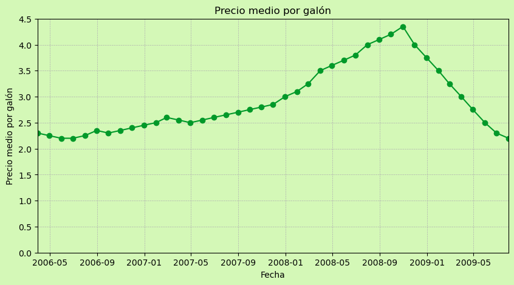

**Figura 1.2** Varias Gráficas de series de tiempo

```python
import matplotlib.pyplot as plt
import pandas as pd

# Ajustamos las fechas para que coincidan con el número de valores proporcionados del Dow Jones
fechas = pd.date_range(start="1998-01-01", periods=15, freq='A-DEC')

# Valores aproximados del Promedio industrial Dow Jones extraídos del gráfico
valores_dow_jones = [
    8200,  9100, 10700, 9800,  8800,  9000, 10200, 10400, 11000,
    12400, 13000, 12800, 11800, 9000,  8500
]

# Crear un DataFrame con los datos ajustados
datos_dow_jones = pd.DataFrame({'Año': fechas, 'Promedio industrial Dow Jones': valores_dow_jones})

# Configuración de la gráfica
plt.figure(figsize=(10, 5))
plt.plot(datos_dow_jones['Año'], datos_dow_jones['Promedio industrial Dow Jones'], color='#009929')
plt.grid(True, which='both', linestyle='--', linewidth=0.5)
plt.title('(A) Promedio industrial Dow Jones')
plt.xlabel('Año', fontweight='bold')
plt.ylabel('Promedio industrial Dow Jones')
plt.ylim(5000, 14000)  # Establecer los límites del eje y
plt.xlim(datos_dow_jones['Año'].min(), datos_dow_jones['Año'].max())  # Establecer los límites del eje x

# Color de fondo
ax = plt.gca()
ax.set_facecolor('#D4F8B7')  # Color de fondo claro
fig = plt.gcf()
fig.patch.set_facecolor('#D4F8B7')  # Color de fondo para la figura

# Mostrar la gráfica
plt.show()
```

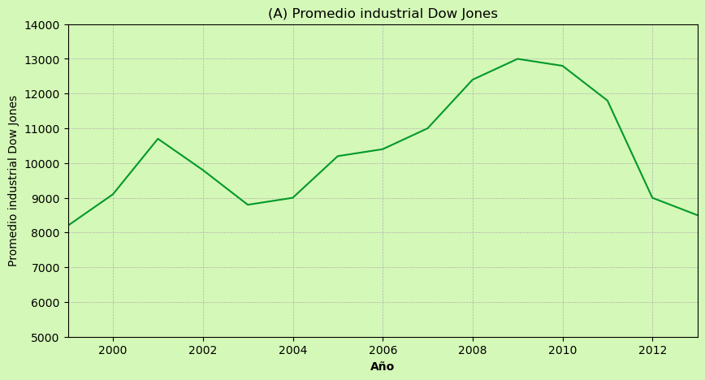

```python
import matplotlib.pyplot as plt
import pandas as pd

# Años representados en el gráfico
años = [2003, 2004, 2005, 2006, 2007, 2008, 2009]

# Valores aproximados de la utilidad neta de McDonald's (en millones de $) extraídos del gráfico
utilidades = [
    1.5, 2.0, 2.5, 2.0, 3.5, 4.0, 5.5
]

# Crear un DataFrame para los datos
datos_utilidad_mcdonalds = pd.DataFrame({'Año': años, 'Utilidad neta (millones $)': utilidades})

# Configuración del gráfico de barras con bordes negros
plt.figure(figsize=(8, 6))
plt.bar(datos_utilidad_mcdonalds['Año'],
        datos_utilidad_mcdonalds['Utilidad neta (millones $)'],
        color='#5CCB5F',
        edgecolor='black')  # Agregar borde negro a las barras
plt.title('(B) Utilidad neta de McDonald’s Inc.')
plt.xlabel('Año', fontweight='bold')
plt.ylabel('Utilidad neta (millones $)')
plt.ylim(0, 6)  # Establecer los límites del eje y

# Color de fondo
ax = plt.gca()
ax.set_facecolor('#D4F8B7')  # Color de fondo claro
fig = plt.gcf()
fig.patch.set_facecolor('#D4F8B7')  # Color de fondo para la figura

# Mostrar el gráfico de barras
plt.show()
```

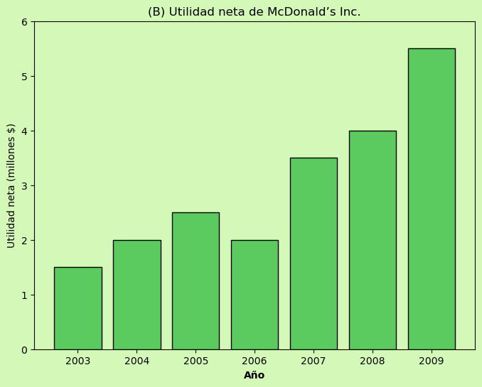

```python
import matplotlib.pyplot as plt
import pandas as pd

# Meses representados en el gráfico
meses = ['Ene', 'Feb', 'Mar', 'Abr', 'May', 'Jun', 'Jul', 'Ago', 'Sep', 'Oct', 'Nov', 'Dic']

# Valores aproximados de la tasa de ocupación de los hoteles del sur de Florida (en porcentaje)
tasas_ocupacion = [
    70, 80, 82, 75, 68, 65, 60, 55, 58, 62, 68, 75
]

# Crear un DataFrame para los datos
datos_ocupacion_hoteles = pd.DataFrame({'Mes': meses, 'Porcentaje de ocupación': tasas_ocupacion})

# Configuración del gráfico de barras
plt.figure(figsize=(10, 6))
plt.bar(datos_ocupacion_hoteles['Mes'], datos_ocupacion_hoteles['Porcentaje de ocupación'], color='#5CCB5F', edgecolor='black')
plt.title('(C) Tasa de ocupación de los hoteles del sur de Florida')
plt.xlabel('Mes', fontweight='bold')
plt.ylabel('Porcentaje de ocupación')
plt.ylim(0, 100)  # Establecer los límites del eje y

# Color de fondo
ax = plt.gca()
ax.set_facecolor('#D4F8B7')  # Color de fondo claro
fig = plt.gcf()
fig.patch.set_facecolor('#D4F8B7')  # Color de fondo para la figura

# Mostrar el gráfico de barras
plt.show()
```

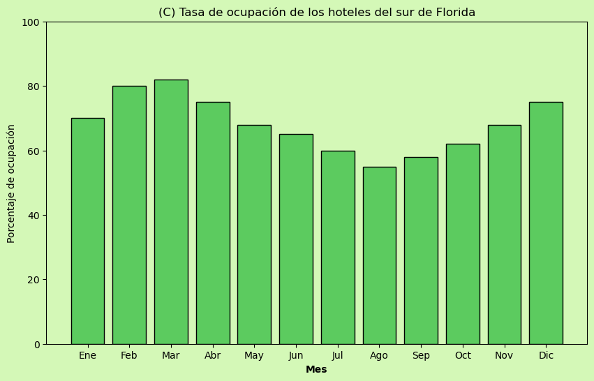

## 1.3 **Fuentes de datos**

Los datos se obtienen de fuentes existentes o a través de encuestas y estudios experimentales.

```python
YouTubeVideo('lY81LgDZvVI', width=950, height=515)
```

[video not shown]

Las empresas suelen contar con bases de datos internas que contienen información sobre empleados, clientes y operaciones comerciales. Los registros internos de personal proporcionan datos como salarios, edades y años de experiencia de los empleados. Otros registros internos contienen información sobre ventas, publicidad, distribución, inventario y producción. Las empresas también pueden obtener datos externos económicos y comerciales a través de organizaciones especializadas en la recolección y almacenamiento de datos. Empresas como Dun & Bradstreet, Bloomberg, Dow Jones & Company, ACNielsen e Information Resources, Inc. proporcionan servicios de bases de datos a clientes. Otras fuentes de datos incluyen asociaciones industriales y organizaciones especializadas, como la asociación Travel Industry Association of America, que proporciona información sobre viajes, y el Graduate Management Admission Council, que tiene datos sobre calificaciones en exámenes y programas educativos para administradores. Internet se ha convertido en una fuente importante de datos y está disponible tanto a través de las páginas web de empresas como a través de plataformas especializadas que ofrecen una amplia variedad de información. Los gobiernos también son una fuente significativa de datos, como el Departamento del Trabajo de Estados Unidos, que proporciona datos sobre empleo, salarios, fuerza laboral, entre otros. Muchas agencias gubernamentales también ofrecen datos en línea a través de sus sitios web.

**Tabla 1.2** Ejemplos de datos disponibles de los registros internos de una empresa

| Fuente | Algunos datos comúnmente disponibles |
| --- | --- |
| Registros de empleados | Nombre, domicilio, número de Seguro Social, sueldo, número de días de vacaciones, número de días de incapacidad y bonos |
| Registros de producción | Número de parte o de producto, cantidad producida, costo de mano de obra directa y costo de los materiales |
| Registros de inventarios | Número de parte o de producto, cantidad de unidades disponible, punto de reorden, lote económico y programa de descuentos |
| Registros de ventas | Número de producto, volumen de ventas, volumen de ventas por región y volumen de ventas por tipo de cliente |
| Registros de crédito | Nombre del cliente, domicilio, número telefónico, límite de crédito y saldo de las cuentas por cobrar |
| Perfiles de clientes | Edad, género, nivel de ingresos, número de miembros en la familia, domicilio y preferencias |

**Tabla 1.3** Ejemplos de datos disponibles de algunas agencias gubernamentales

| Agencia gubernamental | Algunos datos disponibles |
| --- | --- |
| Oficina del Censo | Datos poblacionales, número de familias e ingresos por familia |
| Consejo de la Reserva Federal | Datos sobre la masa monetaria, crédito a plazo, tipos de cambio y tasas de descuento |
| Oficina de Administración y Presupuesto | Datos sobre ingresos, gastos y deudas del gobierno federal |
| Departamento de Comercio | Datos sobre la actividad comercial, valor de las remesas por industria, nivel de utilidades por industria e industrias en crecimiento y en declive |
| Oficina de Estadísticas Laborales | Gasto de los consumidores, ganancias por hora, tasa de desempleo, registros de seguridad y estadísticas internacionales |

### **Estudios estadísticos**

En algunos casos, los datos necesarios no están disponibles y se requiere realizar estudios estadísticos, ya sea experimentales u observacionales, para recopilar la información requerida. Los estudios experimentales buscan establecer una relación causal entre variables, mientras que los estudios observacionales se centran en la observación de fenómenos sin intervenir directamente en ellos. El análisis estadístico de los datos experimentales ayuda a determinar el efecto del nuevo medicamento sobre la presión sanguínea. En los estudios estadísticos no experimentales y observacionales, no se controlan las variables de interés. Un tipo común de estudio observacional es la encuesta, donde se presenta un cuestionario a los individuos de la muestra para obtener información. Los estudios observacionales son utilizados en diversos ámbitos, como la industria de restaurantes, para recopilar datos sobre la calidad de los alimentos, el servicio, etc. Los directivos deben ser conscientes del tiempo y costo requeridos para obtener datos, y en casos de limitaciones de tiempo, es preferible utilizar fuentes de datos existentes. Es importante considerar los posibles errores en la adquisición de datos y asegurarse de que los datos utilizados sean precisos y representativos. Los errores en la adquisición de datos ocurren en diferentes formas y pueden afectar la validez y utilidad de los análisis estadísticos. Es fundamental utilizar métodos precisos para evitar errores en la recopilación de datos

### **Errores en la adquisición de los datos**

Los errores en la adquisición de datos pueden ocurrir de diversas formas, como errores de escritura, malinterpretación de preguntas o respuestas incorrectas dadas por el entrevistado. Los analistas de datos experimentados toman precauciones al recolectar y registrar los datos para evitar errores. Se utilizan procedimientos especiales para verificar la consistencia interna de los datos y revisar valores inusualmente altos o bajos, llamados observaciones atípicas, que pueden indicar posibles errores en los datos. Es importante adquirir datos precisos para evitar la toma de decisiones erróneas basadas en información desorientadora.